# Week 4 Tidymodels & GLM

# 1 Tidymodels

Last week we looked at the tidymodels pipeline for the first time. broom (tidy, glance, augment), rsample (splitting data), parsnip (specifying models), and yardstick (evaluating models). For a brief review look at the solution to coding warmup 3 part 4.

Some more helpful tools.

Checking model specification

```r
parsnip::rand_forest() %>%
  set_engine("ranger") %>%
  set_mode("regression") %>%
  translate()
```

```
## Random Forest Model Specification (regression)
##
## Computational engine: ranger
##
## Model fit template:
## ranger::ranger(x = missing_arg(), y = missing_arg(), weights = missing_arg(),
##     num.threads = 1, verbose = FALSE, seed = sample.int(10^5,
##         1))
```

```r
#?rand_forest

rand_forest(trees = 1000, min_n = 5) %>%
  set_engine("ranger", verbose = TRUE) %>%
  set_mode("regression") %>%
  translate()
```

```
## Random Forest Model Specification (regression)
##
## Main Arguments:
##   trees = 1000
##   min_n = 5
##
## Engine-Specific Arguments:
##   verbose = TRUE
##
## Computational engine: ranger
##
## Model fit template:
## ranger::ranger(x = missing_arg(), y = missing_arg(), weights = missing_arg(),
##     num.trees = 1000, min.node.size = min_rows(~5, x), verbose = TRUE,
##     num.threads = 1, seed = sample.int(10^5, 1))
```

```r
#parsnip_addin()
```

As an aside, what is a random forest? It is an ensemble model (meaning it aggregates information from multiple models) which uses numerous decision trees to make predictions (many trees make a forest). In a classification case, usually the prediction is the class selected by the most trees. In the regression case, the average prediction from individual trees is returned.

# 2 GLM

Let’s run a very basic example on [Lending Club data](https://probably.tidymodels.org/articles/where-to-use.html).

```r
library(modeldata)
data("lending_club")

glimpse(lending_club)
```

```
## Rows: 9,857
## Columns: 23
## $ funded_amnt                <int> 16100, 32000, 10000, 16800, 3500, 10000, 11~
## $ term                       <fct> term_36, term_60, term_36, term_60, term_36~
## $ int_rate                   <dbl> 13.99, 11.99, 16.29, 13.67, 7.39, 11.47, 5.~
## $ sub_grade                  <fct> C4, C1, D1, C3, A4, B5, A1, B2, B3, C2, C3,~
## $ addr_state                 <fct> CT, MN, OH, NV, CA, TX, KY, MO, NY, GA, NH,~
## $ verification_status        <fct> Not_Verified, Verified, Source_Verified, Ve~
## $ annual_inc                 <dbl> 35000, 72000, 72000, 101000, 50100, 32000, ~
## $ emp_length                 <fct> emp_5, emp_ge_10, emp_ge_10, emp_lt_1, emp_~
## $ delinq_2yrs                <int> 0, 0, 0, 0, 0, 0, 0, 2, 0, 1, 0, 0, 0, 1, 0~
## $ inq_last_6mths             <int> 0, 0, 2, 0, 0, 0, 0, 0, 2, 0, 3, 3, 0, 0, 1~
## $ revol_util                 <dbl> 67.4, 82.2, 74.2, 64.0, 78.3, 68.1, 54.8, 3~
## $ acc_now_delinq             <int> 0, 0, 0, 0, 0, 0, 0, 0, 0, 0, 0, 0, 0, 0, 0~
## $ open_il_6m                 <int> 1, 5, 3, 6, 0, 1, 2, 8, 1, 0, 3, 1, 2, 1, 2~
## $ open_il_12m                <int> 0, 1, 2, 1, 0, 0, 0, 2, 0, 0, 1, 2, 1, 0, 4~
## $ open_il_24m                <int> 0, 3, 3, 2, 0, 0, 0, 5, 0, 0, 1, 5, 1, 0, 6~
## $ total_bal_il               <int> 1099, 49187, 33378, 55445, 0, 7574, 20998, ~
## $ all_util                   <int> 48, 77, 79, 64, 78, 66, 54, 80, 75, 36, 43,~
## $ inq_fi                     <int> 0, 0, 1, 1, 0, 0, 0, 0, 2, 1, 1, 1, 0, 1, 7~
## $ inq_last_12m               <int> 3, 0, 4, 4, 0, 0, 0, 4, 6, 1, 3, 5, 1, 0, 5~
## $ delinq_amnt                <int> 0, 0, 0, 0, 0, 0, 0, 0, 0, 0, 0, 0, 0, 0, 0~
## $ num_il_tl                  <int> 3, 9, 9, 10, 3, 9, 7, 21, 7, 1, 7, 19, 7, 6~
## $ total_il_high_credit_limit <int> 13193, 65945, 39387, 60188, 0, 12131, 39486~
## $ Class                      <fct> good, good, good, good, good, good, good, g~
```

```r
lending_club <- lending_club %>%
  mutate(Class = relevel(Class, "good"))

lending_club_mini <- lending_club %>%
  select(Class, annual_inc, verification_status, sub_grade)

lending_club_mini %>% count(Class)
```

| Class | n |
| --- | --- |
| good | 9340 |
| bad | 517 |

Each row is a loan which is either Classified as good or bad.

```r
show_engines("logistic_reg")
```

| engine | mode |
| --- | --- |
| glm | classification |
| glmnet | classification |
| LiblineaR | classification |
| spark | classification |
| keras | classification |
| stan | classification |
| brulee | classification |

```r
split <- initial_split(lending_club_mini)

train <- training(split)
test <- testing(split)

train %>% count(Class)
```

| Class | n |
| --- | --- |
| good | 7005 |
| bad | 387 |

We can see that there is a really large class imbalance. Most loans are good. This is something to watch out for! If our model ‘predicts’ every situation as good it will perform deceptively well.

```r
log_model <- logistic_reg() %>%
  set_engine('glm') %>%
  set_mode('classification') %>%
  fit(Class ~ annual_inc + verification_status + sub_grade,
      data = train)

log_model %>% tidy()
```

| term | estimate | std.error | statistic | p.value |
| --- | --- | --- | --- | --- |
| (Intercept) | -5.203664e+00 | 5.912702e-01 | -8.80082249 | 1.358170e-18 |
| annual_inc | 1.423934e-06 | 9.886871e-07 | 1.44022677 | 1.498033e-01 |
| verification_statusSource_Verified | 4.578449e-02 | 1.410139e-01 | 0.32468063 | 7.454228e-01 |
| verification_statusVerified | 2.115456e-01 | 1.450028e-01 | 1.45890725 | 1.445906e-01 |
| sub_gradeA2 | -2.351925e-01 | 1.158265e+00 | -0.20305590 | 8.390913e-01 |
| sub_gradeA3 | 6.909194e-01 | 8.210430e-01 | 0.84151434 | 4.000599e-01 |
| sub_gradeA4 | -3.312545e-01 | 1.158238e+00 | -0.28599857 | 7.748792e-01 |
| sub_gradeA5 | 9.448456e-01 | 7.119087e-01 | 1.32720049 | 1.844424e-01 |
| sub_gradeB1 | 7.977799e-01 | 7.111029e-01 | 1.12189094 | 2.619088e-01 |
| sub_gradeB2 | 5.811782e-01 | 7.343734e-01 | 0.79139327 | 4.287145e-01 |

[output cut: 28 more lines]

```r
# log_model %>%
#   car::vif()

log_model %>% extract_fit_engine() %>%
  car::vif()
```

```
##                         GVIF Df GVIF^(1/(2*Df))
## annual_inc          1.028086  1        1.013946
## verification_status 1.095369  2        1.023034
## sub_grade           1.117908 34        1.001640
```

Multicollinearity is a big issue. If variables are correlated to both the target variable(s) and themselves, the model will not be able to distuingish between their influence. Variance Inflation Factors, (vif 1, orthogonal/uncorrelated, >5 issue).

```r
preds <- log_model %>%
  predict(test, type='prob')

preds <- log_model %>%
  predict(test, type='class')

test_preds <- log_model %>% augment(test)

test_preds %>% select(Class, .pred_class, .pred_good, .pred_bad)
```

| Class | .pred_class | .pred_good | .pred_bad |
| --- | --- | --- | --- |
| good | good | 0.9172474 | 8.275263e-02 |
| good | good | 0.9728604 | 2.713963e-02 |
| good | good | 0.9701146 | 2.988543e-02 |
| good | good | 0.9601188 | 3.988117e-02 |
| good | good | 0.9542949 | 4.570508e-02 |
| good | good | 0.9581237 | 4.187631e-02 |
| good | good | 0.9706331 | 2.936687e-02 |
| good | good | 0.9341078 | 6.589217e-02 |
| good | good | 0.9639916 | 3.600837e-02 |
| good | good | 0.9601188 | 3.988117e-02 |

[output cut: 2455 more lines]

We can predict a class metric or a class probability metric (recall from yardstick).

```r
test_preds %>% count(Class, .pred_class)
```

| Class | .pred_class | n |
| --- | --- | --- |
| good | good | 2333 |
| good | bad | 2 |
| bad | good | 130 |

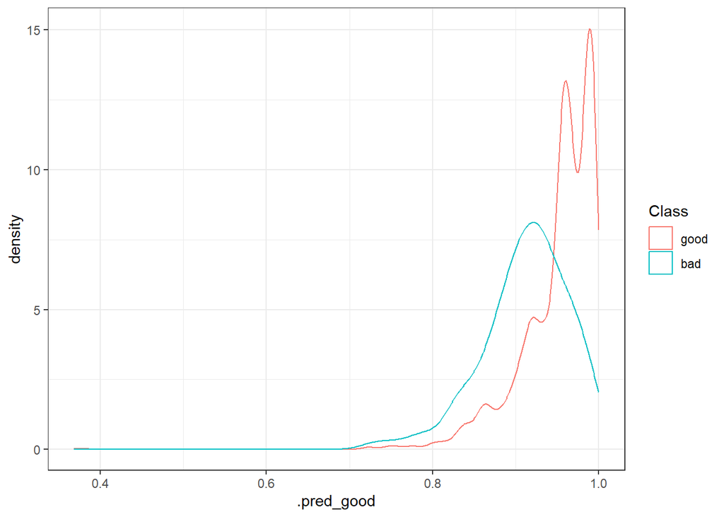

```r
ggplot(test_preds, aes(x=.pred_good, color=Class)) + geom_density()
```

```r
test_preds %>% group_by(Class) %>% summarize(mean(.pred_good), median(.pred_good))
```

| Class | mean(.pred_good) | median(.pred_good) |
| --- | --- | --- |
| good | 0.9506677 | 0.9604447 |
| bad | 0.9123124 | 0.9205804 |

```r
roc_auc(test_preds,
        truth = Class,
        estimate = .pred_good)
```

| .metric | .estimator | .estimate |
| --- | --- | --- |
| roc_auc | binary | 0.740252 |

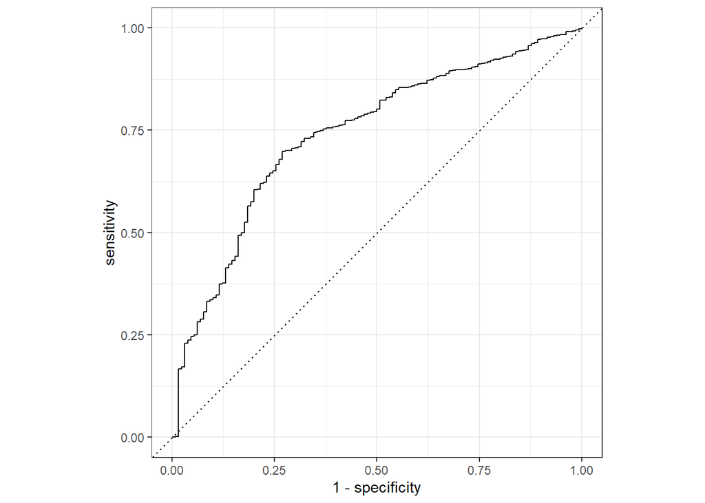

```r
roc_curve(test_preds,
        truth = Class,
        estimate = .pred_good) %>%
  autoplot()
```

```r
specificity(test_preds,
        truth = Class,
        estimate = .pred_class )
```

| .metric | .estimator | .estimate |
| --- | --- | --- |
| specificity | binary | 0 |

```r
sensitivity(test_preds,
        truth = Class,
        estimate = .pred_class)
```

| .metric | .estimator | .estimate |
| --- | --- | --- |
| sensitivity | binary | 0.9991435 |

```r
test_preds %>% count(.pred_class)
```

| .pred_class | n |
| --- | --- |
| good | 2463 |
| bad | 2 |

The `probably` package lets us find the threshold which maximizes sensitivity (true positives) and specificity (true negatives).

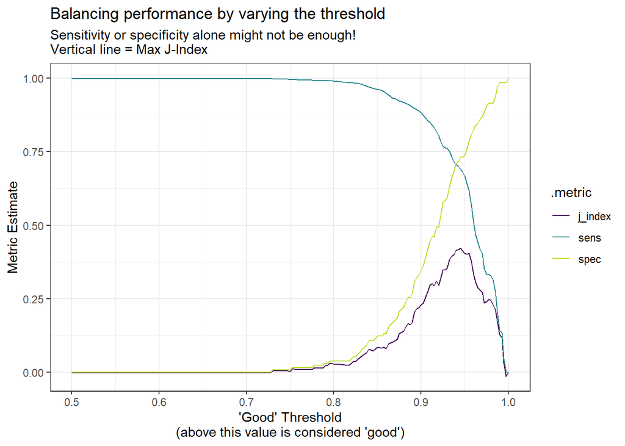

```r
threshold_data <- test_preds %>%
  probably::threshold_perf(Class, .pred_good, thresholds = seq(0.5, 1, by = 0.0025))


ggplot(threshold_data %>% filter(.metric != 'distance'),
       aes(x = .threshold, y = .estimate, color = .metric)) +
  geom_line() +
  scale_color_viridis_d(end = 0.9) +
  scale_alpha_manual(values = c(.4, 1), guide = "none") +
  labs(
    x = "'Good' Threshold\n(above this value is considered 'good')",
    y = "Metric Estimate",
    title = "Balancing performance by varying the threshold",
    subtitle = "Sensitivity or specificity alone might not be enough!\nVertical line = Max J-Index"
  )
```

```r
max_threshold <- threshold_data %>% filter(.metric == 'j_index') %>%
  filter(.estimate==max(.estimate)) %>%
  pull(.threshold)

test_preds2 <- test_preds %>%
  mutate(.pred = probably::make_two_class_pred(.pred_good, levels(Class), threshold = max_threshold)) %>%
  select(Class, contains(".pred"))

test_preds2 %>% count(.pred)
```

| .pred | n |
| --- | --- |
| good | 1648 |
| bad | 817 |

```r
precision(test_preds2,
        truth = Class,
        estimate = .pred_class)
```

| .metric | .estimator | .estimate |
| --- | --- | --- |
| precision | binary | 0.9472188 |

```r
recall(test_preds2,
        truth = Class,
        estimate = .pred_class)
```

| .metric | .estimator | .estimate |
| --- | --- | --- |
| recall | binary | 0.9991435 |

```r
f_meas(test_preds2,
        truth = Class,
        estimate = .pred_class)
```

| .metric | .estimator | .estimate |
| --- | --- | --- |
| f_meas | binary | 0.9724885 |

# 3 Regularlized Regression

```r
split <- initial_split(lending_club)

train <- training(split)
test <- testing(split)


log_model2 <- logistic_reg(penalty = 0.1) %>%
  set_engine('glmnet') %>%
  set_mode('classification') %>%
  fit(Class ~ .,
      data = train)

log_model2 %>% tidy() %>% filter(abs(estimate) > 0)
```

| term | estimate | penalty |
| --- | --- | --- |
| (Intercept) | -2.861057 | 0.1 |

```r
log_model3 <- logistic_reg(penalty = 0.01) %>%
  set_engine('glmnet') %>%
  set_mode('classification') %>%
  fit(Class ~ .,
      data = train)

log_model3 %>% tidy() %>% filter(abs(estimate) > 0)
```

| term | estimate | penalty |
| --- | --- | --- |
| (Intercept) | -4.68801730 | 0.01 |
| int_rate | 0.12410208 | 0.01 |
| open_il_12m | 0.06248762 | 0.01 |
| inq_fi | 0.02934769 | 0.01 |

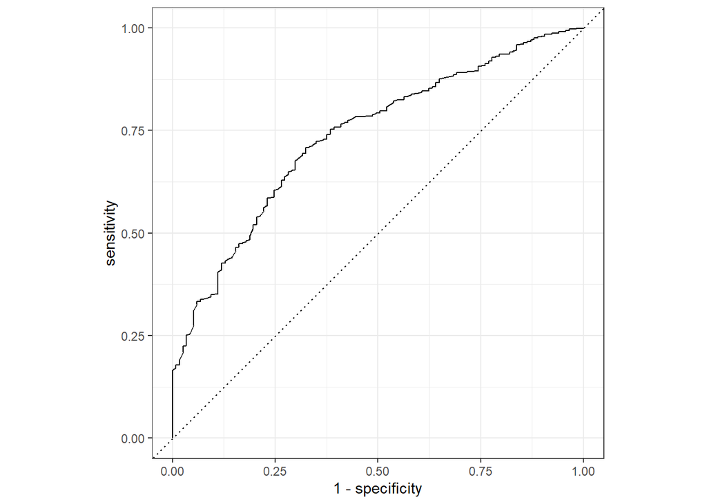

```r
test_preds_l3 <- log_model3 %>% augment(test)

roc_curve(test_preds_l3,
        truth = Class,
        estimate = .pred_good) %>%
  autoplot()
```

```r
roc_auc(test_preds_l3,
        truth = Class,
        estimate = .pred_good)
```

| .metric | .estimator | .estimate |
| --- | --- | --- |
| roc_auc | binary | 0.7364023 |

```r
log_model4 <- logistic_reg(penalty = 0.001) %>%
  set_engine('glmnet') %>%
  set_mode('classification') %>%
  fit(Class ~ .,
      data = train)

log_model4 %>% tidy() %>% filter(abs(estimate) > 0)
```

| term | estimate | penalty |
| --- | --- | --- |
| (Intercept) | -5.342111e+00 | 0.001 |
| funded_amnt | 2.656272e-06 | 0.001 |
| termterm_60 | -3.404180e-01 | 0.001 |
| int_rate | 1.605080e-01 | 0.001 |
| sub_gradeA2 | -3.515330e-01 | 0.001 |
| sub_gradeA4 | -6.659451e-01 | 0.001 |
| sub_gradeB2 | -7.606505e-01 | 0.001 |
| sub_gradeC1 | 1.062150e-01 | 0.001 |
| sub_gradeC4 | 1.408598e-01 | 0.001 |
| sub_gradeC5 | 4.157332e-01 | 0.001 |

[output cut: 61 more lines]

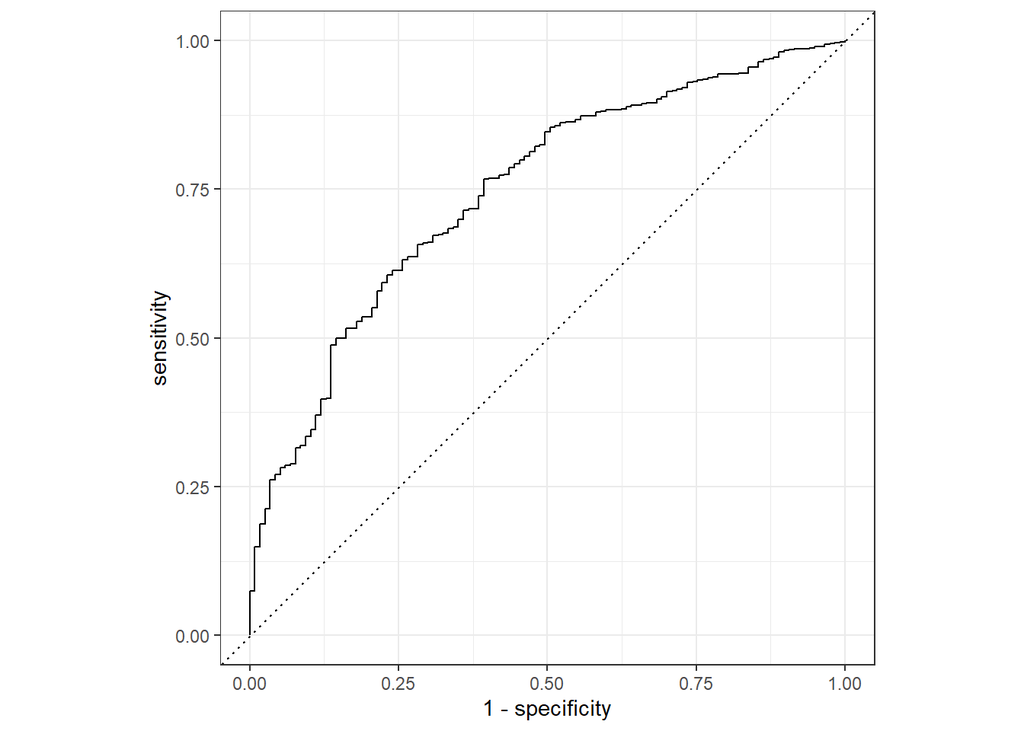

```r
test_preds_l4 <- log_model4 %>% augment(test)

roc_curve(test_preds_l4,
        truth = Class,
        estimate = .pred_good) %>%
  autoplot()
```

```r
roc_auc(test_preds_l4,
        truth = Class,
        estimate = .pred_good)
```

| .metric | .estimator | .estimate |
| --- | --- | --- |
| roc_auc | binary | 0.7453297 |